# Mapeamento por intervalo múltiplo

Anna Letycia B. Garcia<sup>1</sup>, Germano Martins F. Costa-Neto<sup>2</sup>, Nathália Salgado Silva<sup>3</sup>, Rafael Massahiro Yassue<sup>2</sup>** <sup>1</sup> Bioinformatics Applied to Bioenergy Laboratory, University of São Paulo (ESALQ/USP). <sup>2</sup> Allogamous Plant Breeding Laboratory, University of São Paulo (ESALQ/USP). <sup>3</sup> Genetic Diversity and Plant Breeding Laboratory, University of São Paulo (ESALQ/USP).

05 de julho de 2019

## Data set

Este trabalho usará o conjunto de dados oriundo de Fishman et al (2001). O objetivo aqui será o de realizar o mapeamento de QTL para a carcterística 4 (*leaf lenght*). Essa característica foi escolhida arbitrariamente.

No trabalho de Fishman et al. (2002) vemos que essa caracteristida tem herdabilidade (sentido amplo) $h^2 = 0.39$, sendo, inclusive, uma das características com menor valor para esse parametro. Desse modo, espera-se que essa caracteristica seja de herança quantitativa, poligenica e por isso vinculada a pelo menos um QTL. Aqui neste trabalho será demonstrado o método de mapeamento por intervalo múltiplo (MIM). Por fim, os resultados obtidos serão comparados aos encontrados pelo método IM e CIM.

As análises foram realizadas usando o pacote R/qtl (Broman et al 2003).

Primeiramente, verificamos a prenseça de dados faltantes e aplicamos a imputação de informação assumindo possíveis erros de genotipagem a uma taxa de 1%. O ajuste do mapa foi realizado com base na função de mapeamento de Kosambi (1944).

Os codigos desta análise estarão disponíveis [aqui](https://github.com/biomarkUSP/mimulus/blob/master/MIM.R).

A análise completa de mapeamento IM e CIM está disponível [aqui](https://biomarkusp.github.io/mimulus/Mapeamento.html). Ressalta-se que o que fora feito daqui em diante difere do presente nesse link. Aqui neste trabalho, fomos menso rigorosos em no valor de $\alpha$ e ainda apresentamos algumas outras figuras.

Os trabalhos de mapeamento de QTL foram baseados no mapa de ligação descrito [aqui](https://biomarkusp.github.io/mimulus/linkagemap.html). O data set utilizado neste estudo pode ser baixado [nesse link](https://github.com/biomarkUSP/mimulus).

## Mapeamento Intervalar (IM)

O IM foi realizado usando o nível de significancia $\alpha$ igual a 10%. O LOD liminar para rejeição de $H_0$ é então igual a **3.49** (n = 800 permutations); Neste cenário, pudemos identificar dois QTL: um localizado no cromossomo 9 (na posição ~48 cM, LOD = 3.66) e 12 (na posição ~ 15 cM, LOD = 4.11).

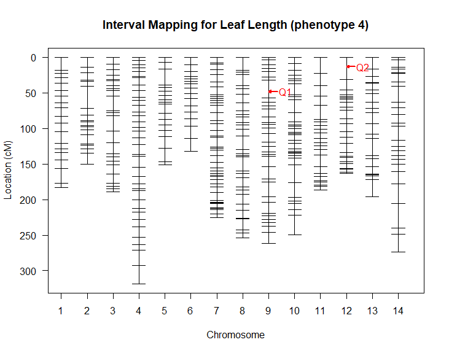

Observa-se em ambos os casos uma região genomica extensa, na qual em ambos os QTL situa-se em regiões com baixa saturação de marcas na qual a presença de um QTL pode ser decorrente da baixa saturação de marcas. Assim, é possível que o aumento da saturação de marcas nessa região possa diminuir essa janela e identificar com maior precisão os limites genomicos do QTL de interesse.

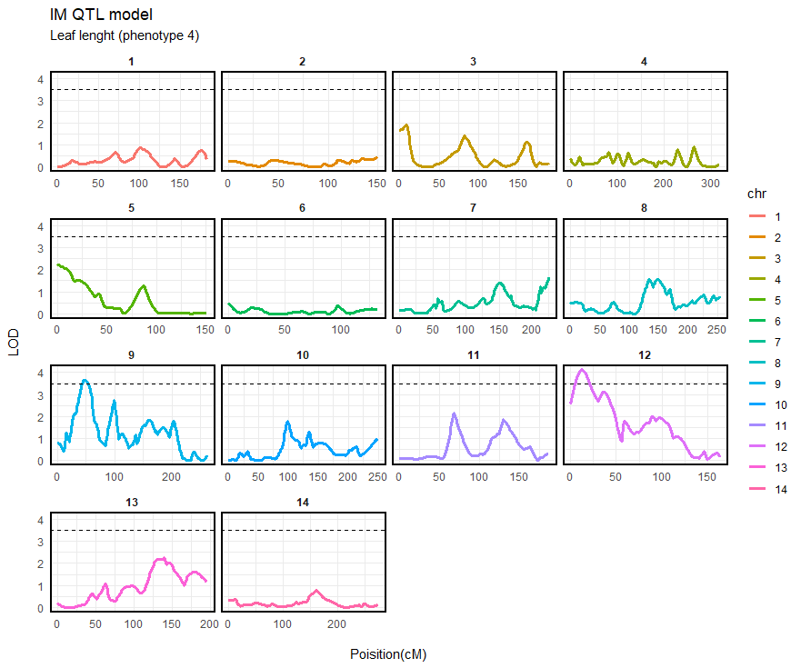

Nas figuras abaixo vemos a distribuição dos efeitos aditivos (azul) e desvios de dominancia (vermelhos) dos QTL detectados. Nas regioes detectadas, para o cromossomo 9,vemos predominancia de efeitos aditivos, enquanto no cromossomo 12 vemos predominancia de efeitos oriundos de desvios de dominancia.

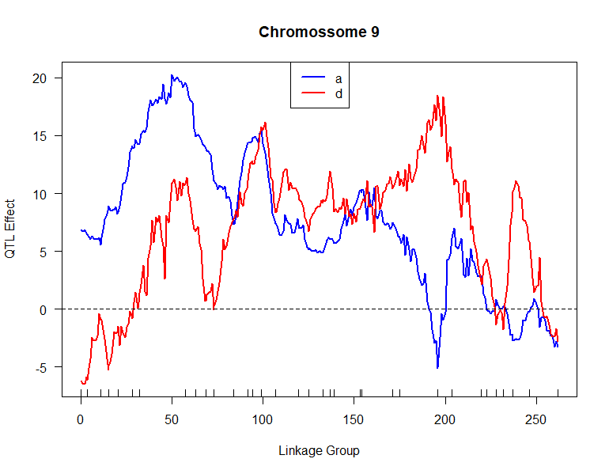

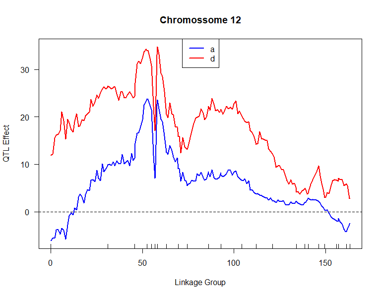

## Mapeamento por Intervalo Composto (CIM)

Visnado refinar a análise realizada anteriormente, buscamos agora inserir cofatores geneticos no modelo. Assim, o modelo IM adquire maior poder de detecção de QTL, podendo eliminar possíveis relações espúrias encontradas na analise anterior. A partir do modelo stepwise, detectamos duas sugestões de QTL:

- $9@490$, localizado no cromossomo 9 na posição 49 cM.
- $12@130$, localizado no cromossomo 12 na posição 13cM.

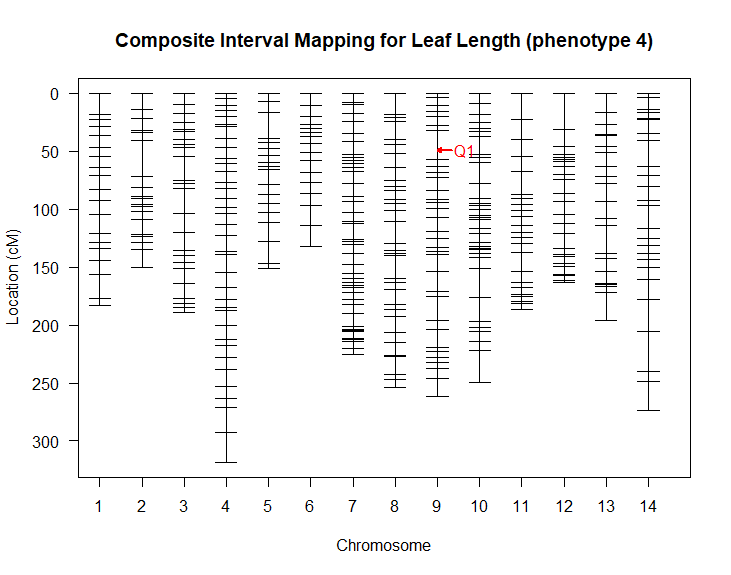

No modelo CIM, contudo, computamos via permutação um novo liminar para rejeião de $H_0$: Neste cenário, computando os LOD a partir do modelo CIM, há apenas sugestão da presença de um QTL referente á posição 49 cM do cromossomo 9.

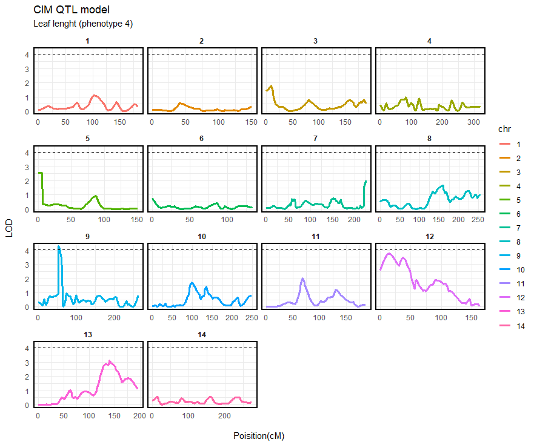

## Mapeamento por Intervalo Múltiplo (MIM)

Finalmente, avançamos para o modelo que integra o uso de cofatores genéticos relacionados à QTLs.

Utilizamos a funcao scantwo() para obter as estatísticas de LOD score considerando o modelo bidimensional de 2-QTL.

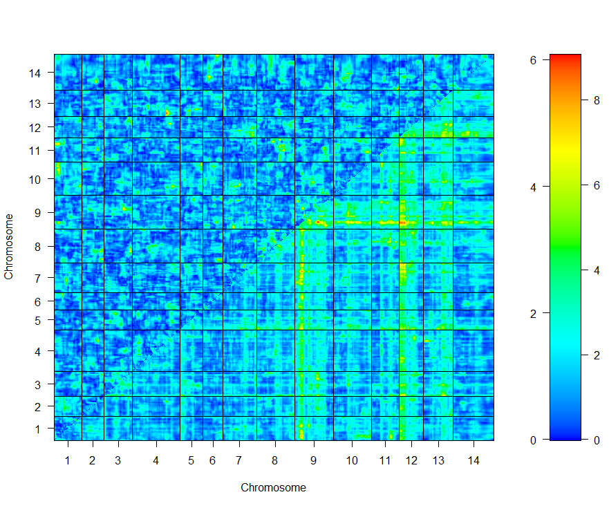

Ha evidencia (mesmo que fraca) de uma possivel interacao entre os QTL localizados nos cromossomos 9 e 12. Plotando apenas efeitos aditivos, podemos contemplar se há alguma relação aditivo-aditivo entre marcas localizadas nesses cromossomos.

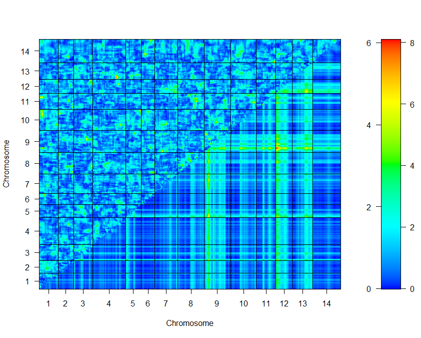

Contudo, a partir da figura de interacao, podemos constatar que essa possível interação apresenta, de certo modo, uma sinergia, onde na situação de heterozigosidade há aumento de ambos os efeitos dos QTL sugeridos.

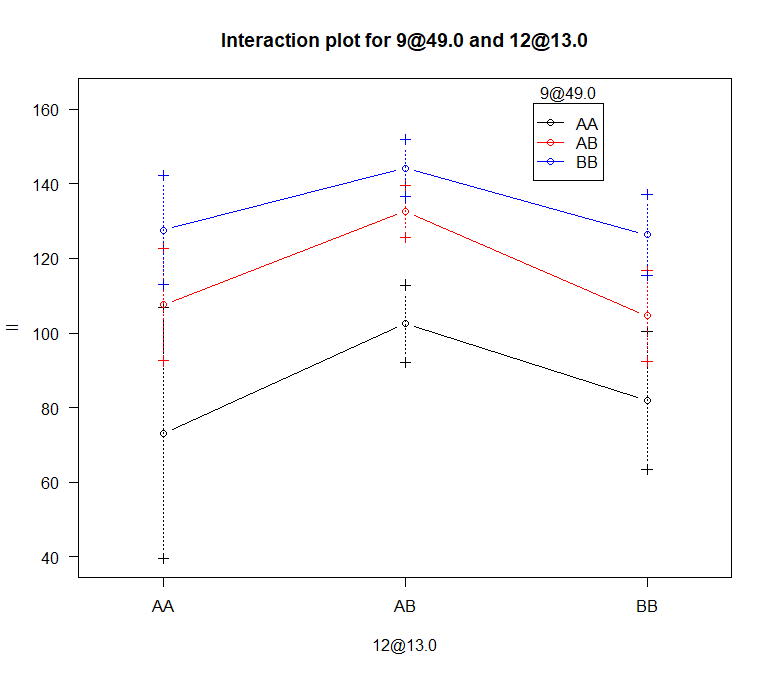

Observa-se que o genótipo heterozigoto apresenta maior efeito do que os homozigotos. Essa é uma possível sugestão de que o QTL tenha efeito maior relação à efeitos de dominancia do que aditivos.

Utilizando essas informações preliminares, traçamos dois modelos MIM. O primeiro não considerando epsistasia e o segundo incluindo-a.

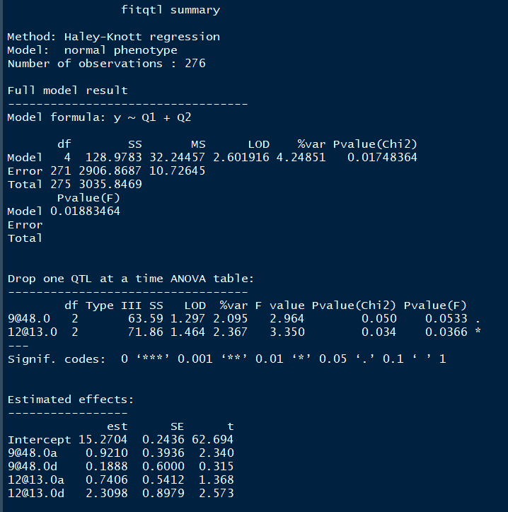

Para o modelo sem epistaria, bbserva-se que que o QTL $9@48$ (Cromossomo 9) apresenta p-valor igual a 5,33% e o QTL $12@13$ apresenta p-valor igual a 3,66% (sendo significativos $\alpha = 0.1$). O modelo MIM ajustado foi capaz de explicar um total de 4,2% da variancia da caracteristica leaf lenght (~2% por QTL).

Observa-se também que arquitetura desse trait é mais influenciada por efeitos de dominancia do que efeitos aditivos.

Como demonstrado no interaction plot, pode haver uma interação tal que haja sinergia entre os efeitos dos QTL. Afim de proceder uma análise investigativa de possíves efeitos de epstasia, ajustamos um novo modelo, agora considerado interação entre os QTL, isto é: $y = Q_1+Q_2+Q_1*Q_2$

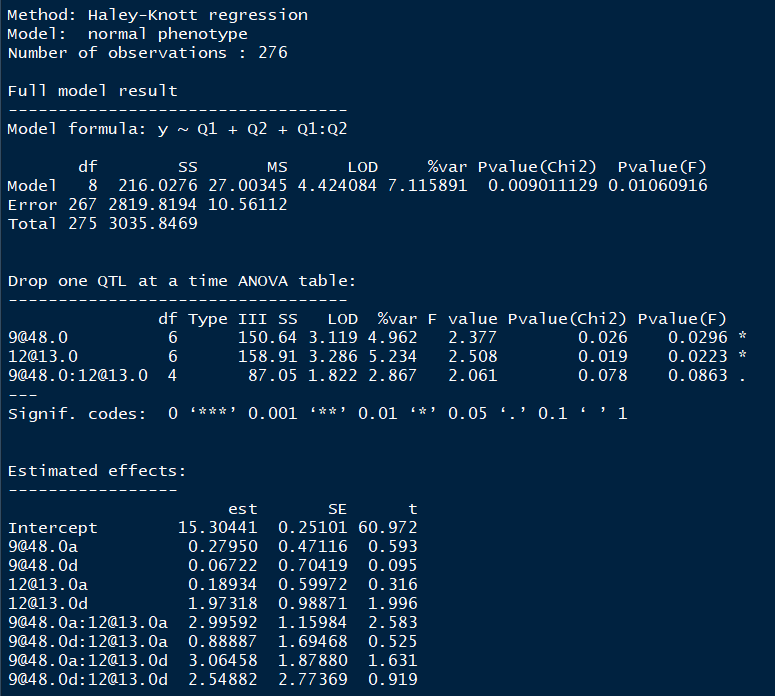

O QTL $9@48$ (cromossomo 9, pos 49cM) explicou quase 5% da variação do fenótipo. Já o QTL $12@13$ (cromossomo 12, pos 13cM) explicou 5,2% da variação do fenótipo. Por fim, a interação entre ambos explicou quase 3% da variação do fenótipo. Contudo, a signifancia desse efeito é de quase 8%, o que pode ser um indicativo de uma possível inconsistencia na modelagem, na qual colocamos o nível de significancia muito alto e então passamos a captar falsos positvos. Ademais, estamos superparametrizando o modelo o que, dado o tamanho da população, pode estar resultando na manifestação do *Beavis effect*.

## Referencias

Broman, K. W., and S. Sen, 2009 **A Guide to QTL Mapping with R/qtl**, Vol. 46. Springer, New York.

Broman, K. W., H. Wu, S. Sen, and G. A. Churchill, 2003 **R/qtl: QTL mapping in experimental crosses**. Bioinformatics 19: 889–890.

Fishman, L.A., Kelly, J., Morgan, E., Willis, J.H., 2001 **A genetic map in the Mimulus guttatus species complex reveals transmission ratio distortion due to heterospecific interactions**. Genetics 159: 1701-1716.

Fishman, L.A., Kelly, J., Morgan, E., Willis, J.H., 2002 **Minor quantitative trait loci underlie floral traits associated with mating system divergence in Mimulus**. Evolution 56: 2138-2155.

Kosambi, D.D., 1944 **The estimation of map distance from recombination values**. Annuaire of Eugenetics 12:172-175.